# Lecture 4 - Solving Kinematic Problems

In this lecture we will discuss problem approaches for kinematics

### Starting Point

- Draw a diagram
- Identify variables and relevant equations
- Identify known and unknown quantities
- Come up with a strategy to get the unknown quantities from the known
- Often it is best to solve problems using algebra as far as possible

### Free fall - Problem 2.69

A stone falling past a window: A free fall problem. We know the window's height and the time it took for the stone to travel this distance. We are asked from what height above the top of the window did the stone fall.

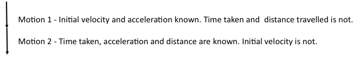

Variables: (y,t)

Equations: Define $y$ ↓ and $g=9.81\,\mathrm{ms}^{-2}$ ↓

$v= v_{0}+gt$

$y= y_{0}+v_{0}t+\frac{1}{2}gt^2$

$v^{2}=v_{0}^2+2g(x-x_{0})$

$g=9.81\,\mathrm{ms}^{-2}$

Knowns: Over a certain time interval we know the distance traveled.

Information required: Initial displacement when $v=0$.

### 2.69 Approach 1

Break the problem in to two motions. Using the equation $y= y_{0}+v_{0}t+\frac{1}{2}gt^2$ we can find out what the velocity was the beginning of the motion for which we know the distance traveled and time taken.

$(y-y_{0})-\frac{1}{2}gt^2=v_{0}t$

$v_{0}=\frac{2.2\mathrm{m}-0.5\times9.8\mathrm{ms}^{-2}\times(0.28)^2\mathrm{s}^{2}}{0.28\mathrm{s}}=6.49\mathrm{ms}^{-1}$

Now we take this velocity and make it the final velocity of a motion that took place immediately before this one. In this motion we know $v$ and $a$ and want to find the distance that the object fell before the motion we just looked at took place.

$v^2=v_{0}^2+2g(y-y_{0})$

Now, our previous $v_{0}$ is $v$ for this segment of motion. Also in this segment $v_{0} = 0$ (falling stone assumes that the initial velocity of the stone was zero).

$y-y_{0}=\frac{v^2-v_{0}^2}{2g}$

And the height the object starts above the windows is the same as the distance it falls through

$h=\frac{(6.49\mathrm{ms}^{-1})^2}{2\times9.81\mathrm{ms}^{-1}}=2.1\mathrm{m}$

### 2.69 Approach 2

A different approach using calculus.

Starting from time $t=0$ the displacement at any time can be expressed as

$\int_{0}^{y}\,dy=\int_{0}^{t}gt\,dt$

Let us define the time at which the stone passes the top of the window as $t_{1}$ and the time it passes the bottom of the window as $t_{2}$.

Integrating between t$_0$=0 and t$_1$ (or y$_0$=0 and y$_1$)

$y_{1}=\frac{1}{2}gt_{1}^{2}$

Integrating between t$_1$ and t$_2$ (or y$_1$ and y$_2$)

$y_{2}-y_{1}=\frac{1}{2}gt_{2}^{2}-\frac{1}{2}gt_{1}^{2}=\frac{g}{2}(t_{2}^{2}-t_{1}^{2})=\frac{g}{2}(t_{2}+t_{1})(t_{2}-t_{1})$

$\frac{y_{2}-y_{1}}{t_{2}-t_{1}}\frac{2}{g}=\frac{2.2\mathrm{m}}{0.28\mathrm{s}}\frac{2}{9.81\mathrm{ms^{-2}}}=1.60\mathrm{s}={t_{2}+t_{1}}$

As $t_{2}=t_{1}+0.28\mathrm{s}$

$t_{1}=\frac{1.60\mathrm{s}-0.28\mathrm{s}}{2}=.66\mathrm{s}$

### Relative Velocity

Dealing with relative velocity is a particularly important application of addition and subtraction of vectors.

We can adopt a notation which can be helpful.

$\vec{v}_{AB}$: velocity of A relative to B

If we want to know the velocity of A relative to C if we know the velocity of A relative to B and the velocity of B relative to C

$\vec{v}_{AC}=\vec{v}_{AB}+\vec{v}_{BC}$

Whereas if we want to find the velocity of B relative to C

$\vec{v}_{BC}=\vec{v}_{AC}-\vec{v}_{AB}$

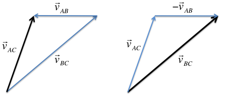

### Problem 3.70

Relative to the water, the boat has a known velocity $v_{BW}$ (including direction $\theta_{BW}$).

The direction of the boat's velocity relative to the land can be deduced as $\tan\theta_{BL}=\frac{118\mathrm{m}}{265\mathrm{m}}$.

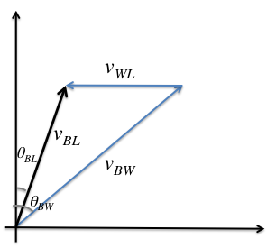

### Problem 3.70 Solution

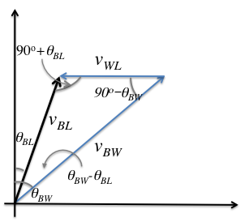

#### Use the sine rule.

$\frac{v_{WL}}{sin(\theta_{BW}-\theta_{BL})}=\frac{v_{BW}}{sin(90^{o}+\theta_{BL})}=\frac{v_{BL}}{\sin(90^{o}-\theta_{BW})}$

### Problem 3.70 Solution

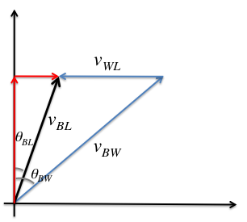

#### Or Use components.

$\frac{v_{BW}\sin\theta_{BW}-v_{WL}}{v_{BW}\cos\theta_{BW}}=\tan\theta_{BL}$.

Recall that tan($\theta_{BL})=\frac{118m}{265m}$

### A canoe on a river

A canoe has a velocity of 0.450 m/s southeast relative to the earth. The canoe is on a river that is flowing 0.520 m/s east relative to the earth. Find the velocity (magnitude and direction) of the canoe relative to the river.

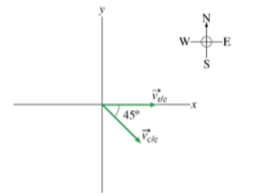

$\vec{v}_{CE}=\vec{v}_{CR}+\vec{v}_{RE}$

$\vec{v}_{CR}=\vec{v}_{CE}-\vec{v}_{RE}$

### Raindrops in the train window

Raindrops make an angle $\theta$ with the vertical when viewed through a moving train window. If the train travels at speed $v_t$, what is the speed of the raindrops in the reference frame of the earth, where thy fall vertically?

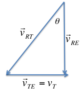

$\vec{v}_{RE}=\vec{v}_{RT}+\vec{v}_{TE}$

### Projectile Motion

| $\Large a_{x}=0$ | $\Large a_{y}=-g$ |
| --- | --- |
| $\Large v_{x}=v_{0,x}$ | $\Large v_{y}=v_{0,y}-gt$ |
| $\Large x=x_0+v_{0,x}$ | $\Large y=y_{0}+v_{0,y} t -\frac{1}{2}gt^{2}$ |

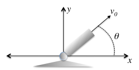

| $\Large a_{x}=0$ | $\Large a_{y}=-g$ |
| --- | --- |
| $\Large v_{x}=v_{0}\cos\theta$ | $\Large v_{y}=v_{0}\sin\theta-gt$ |
| $\Large x=x_0+v_{0}\cos\theta t$ | $\Large y=y_{0}+v_{0}\sin\theta t -\frac{1}{2}gt^{2}$ |

### Problem 3.88

Knowns: x,y at a given t

Useful equations:

| $v_{x}=v_{0}\cos\theta$ | $v_{y}=v_{0}\sin\theta-gt$ |
| --- | --- |
| $x=x_0+v_{0}\cos\theta t$ | $y=y_{0}+(v_{0}\sin\theta) t-\frac{1}{2}gt^{2}$ |

Set $x_{0}=0$ and $y_{0}=0$

| $x=v_{0}\cos\theta t$ | $y=v_{0}\sin\theta t -\frac{1}{2}gt^{2}$ |
| --- | --- |

Need an equation only in term of $v$ or $\theta$

$v_{0}=\frac{x}{\cos\theta t}$

$y=x\frac{\sin\theta t}{\cos\theta t}-\frac{1}{2}gt^{2}=x\tan\theta-\frac{1}{2}gt^{2}$

Solve for $\theta$ and then $v_{0}$

Alternatively, substitute in numbers first, which gives two equations containing $v$ and $\theta$ which can be solved simultaneously. (Much less elegant)

### Problem 3.61

Take a look a the approach used to find the motion path in Lecture 3. Instead of solving for y=0 solve for y=h. Note that the problem only wants you to find the solution for h>0. Also note that Mastering Physics requires that you type trig functions with brackets, e.g $\sin(\theta)$ not $\sin\theta$.

You want to solve the following equation for x

$h=x\frac{\sin\theta_{0}}{\cos\theta_{0}}-\frac{g}{(2v_{0}^{2}\cos^2\theta_{0})}x^2$

Rearranged in to standard quadratic form this is:

$x^2-\frac{2v_{0}^{2}}{g}\sin\theta_{0}\cos\theta_{0} x+h\frac{(2v_{0}^{2}\cos^2\theta_{0})}{g}=0$

I find the best way to move forward is to [complete the square](https://en.wikipedia.org/wiki/Completing_the_square) (though you can use the quadratic formula also)

$x^2-\frac{2v_{0}^{2}}{g}\sin\theta_{0}\cos\theta_{0} x+\frac{v_{0}^4}{g^2}\sin^2\theta_{0}\cos^2\theta_{0}-\frac{v_{0}^4}{g^2}\sin^2\theta_{0}\cos^2\theta_{0} +h\frac{(2v_{0}^{2}\cos^2\theta_{0})}{g}=0$

$x^2-\frac{2v_{0}^{2}}{g}\sin\theta_{0}\cos\theta_{0} x+\frac{v_{0}^4}{g^2}\sin^2\theta_{0}\cos^2\theta_{0}=\frac{v_{0}^4}{g^2}\sin^2\theta_{0}\cos^2\theta_{0} -h\frac{(2v_{0}^{2}\cos^2\theta_{0})}{g}$

$(x-\frac{v_{0}^2}{g}\sin\theta_{0}\cos\theta_{0})^2=\frac{v_{0}^2\cos^2\theta_{0}}{g^2}(v_{0}^2\sin^2\theta_{0}-2gh)$

$x=\frac{v_{0}^2}{g}\sin\theta_{0}\cos\theta_{0}\pm\frac{v_{0}\cos\theta_{0}}{g}\sqrt{v_{0}^2\sin^2\theta_{0}-2gh}$

Only one of the solutions for x is positive if $h\gt0$ and this is the one you are looking for.

$x=\frac{v_{0}\cos\theta_{0}}{g}(v_{0}\sin{\theta_{0}}+\sqrt{v_{0}^2\sin^2\theta_{0}-2gh})$

### Monkey and Hunter

At the moment the hunter pulls the trigger the monkey can make a decision, should he hang on or drop from the tree in the hope the bullet will miss him?

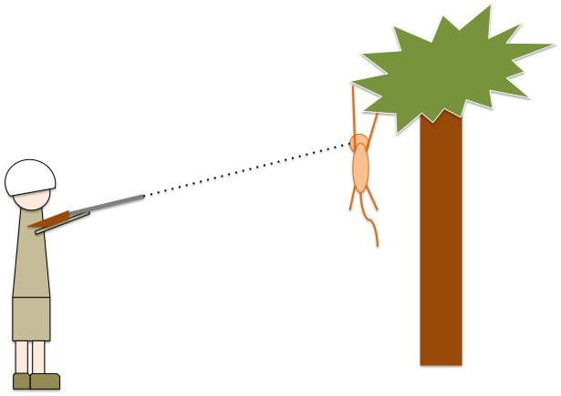

### Monkey and Hunter Solution

You can step through frame by frame and a pretty detailed explanation [here](http://www.animations.physics.unsw.edu.au/jw/monkey_hunter.html)

Height of bullet with time:

$y=x\tan\theta-\frac{1}{2}gt^{2}$

Hunter's expectation:

$y=x\tan\theta$

At monkey's $x$ position, $x_{m}$ the bullet will be $-\frac{1}{2}gt^{2}$ below where monkey started…exactly the same distance the monkey will be below his starting point if he lets go.

This is a simple demonstration of the fact that gravity accelerate all object's equally independently of their horizontal velocity.

```python
y1 = 0.5*9.81*(1.32/2)**2
y1
```

```
2.1366180000000004
```